# Kernel Density Simulation Envelopes

The function `envelope()` in spatstat wraps a simulation procedure for obtaining envelopes for the k-function, g-function, and f-function (possibly others). Unfortunately, it does not work for kernel density estimates. Fortunately, as it turns out, it is not very difficult to create a function to obtain simulation envelopes for kernel density.

This illustrates how to do it.

Load the library `spatstat`:

```r
library(spatstat)
```

Load sample dataset:

```r
load("Data3.RData")
```

The dataframe `PointPatterns` contains a set of four marked point patterns. Convert to `ppp` for analysis using `spatstat`, using a unit-square window:

```r
W <- owin(c(0, 1), c(0, 1))
PointPatterns.ppp <- as.ppp(X = PointPatterns, W = W)
```

Plot the point patterns:

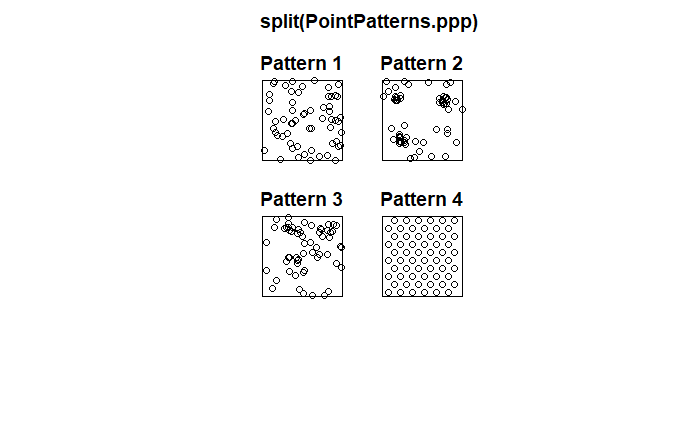

```r
plot(split(PointPatterns.ppp))
```

Obtain kernel density estimates using `density`. This function accepts as an argument `sigma`, the bandwidth.

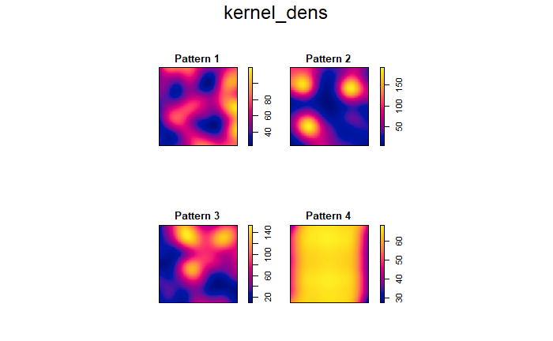

```r
kernel_dens <- density(split(PointPatterns.ppp), sigma = 0.1)
plot(kernel_dens)
```

(Try changing sigma!)

This is the function. It takes as an argument a point pattern in `ppp` format. At the moment, it cannot deal with multitype, so any simulation would have to be done separately for each of the patterns. The other arguments are the number of simulations `nsim` and `sigma`.

```r
den_envelopes <- function(x = ppp, nsim = nsim, sigma = sigma){
  W <- x$window
  n <- x$n
  xden <- density(x)
  sim.ppp <- runifpoint(n = n, W = W, nsim = nsim)
  sim_den <- lapply(sim.ppp, FUN = density, sigma = sigma)
  den_env <- array(data = NA, dim = c(ncol(sim_den[[1]]$v), nrow(sim_den[[1]]$v), nsim))
  for(s in 1:nsim){
    den_env[,,s] <- sim_den[[s]]$v
  }
  max_env <- matrix(data = NA, nrow = nrow(den_env), ncol = ncol(den_env))
  min_env <- matrix(data = NA, nrow = nrow(den_env), ncol = ncol(den_env))
  for(i in 1:nrow(den_env)){
    for(j in 1:ncol(den_env)){
      max_env[i,j] <- max(den_env[i,j,])
      min_env[i,j] <- min(den_env[i,j,])
    }
  }
  #Convert to "im" objects
  max_env <- as.im(max_env, W = W)
  min_env <- as.im(min_env, W = W)
  #Compare the empirical density to the upper and lower envelopes
  max_env <- xden$v >= max_env
  min_env <- xden$v <= min_env
  #Create a list with the results
  as.imlist(list(Max = max_env, Min = min_env))
}
```

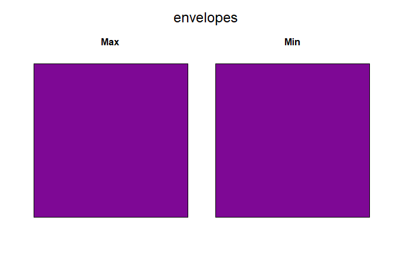

```r
envelopes <- den_envelopes(x = split(PointPatterns.ppp)$"Pattern 1", nsim = 99, sigma = 0.01)
plot(envelopes)
```

Apply the `den_envelopes` function to the second pattern and plot:

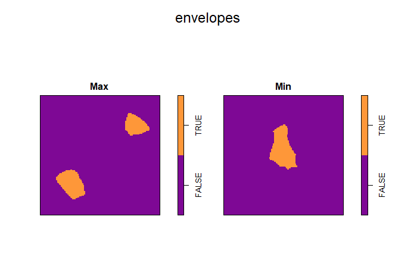

```r
envelopes <- den_envelopes(x = split(PointPatterns.ppp)$"Pattern 2", nsim = 99, sigma = 0.1)
plot(envelopes)
```

Apply the `den_envelopes` function to the third pattern and plot:

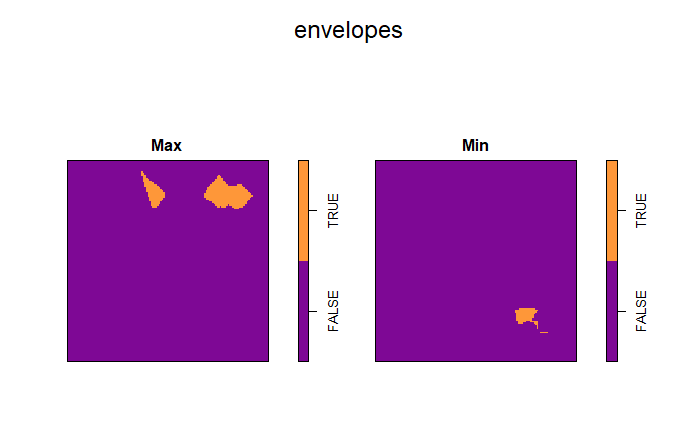

```r
envelopes <- den_envelopes(x = split(PointPatterns.ppp)$"Pattern 3", nsim = 99, sigma = 0.1)
plot(envelopes)
```

Apply the `den_envelopes` function to the fourth pattern and plot:

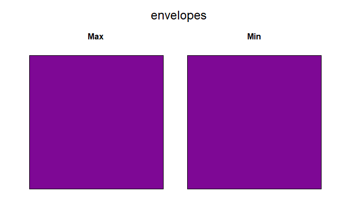

```r
envelopes <- den_envelopes(x = split(PointPatterns.ppp)$"Pattern 4", nsim = 99, sigma = 0.1)
plot(envelopes)
```